# Simulating a Smaller TAM Panel

Arabs 15+, five major cities (1 million+) — 10 samples of 1,000 individuals weighted to the universe and matched against TAM spot results

2026-06-23

## The question

Can a panel of **1,000 Arab individuals aged 15+** in Saudi Arabia’s **five largest cities** (1 million+ population) reproduce the GRP results of the full TAM panel for the same target group?

To find out, we:

1. Restrict the TAM panel to **Arabs (Saudi + Arab Expat), aged 15+**, in households located in **million-plus cities** (Riyadh, Jeddah, Mecca, Medina, Dammam/Eastern Province)
2. Draw **10 independent samples** of 1,000 individuals from this filtered panel
3. **Weight each sample daily** to the Arab 15+ population structure, projecting to a universe of **7,184,452 individuals**
4. Take a real list of **advertising spots** — with GRPs already calculated for the same Arab 15+ / 5-city target — and recompute each spot’s audience from each of the 10 small samples
5. Compare the small-sample GRPs against the TAM benchmark

## Process overview

```
flowchart LR
  A["TAM panel<br/>week 25–31 May 2026<br/>Arabs 15+, 1M+ cities"] --> B["Draw 10 samples<br/>of 1,000 individuals<br/>(Arab, 15+)"]
  B --> C["Rake each sample<br/>day by day<br/>(5 rim dimensions)"]
  C --> D["Project weights<br/>to universe<br/>7,184,452"]
  E["Spot list<br/>(full TAM GRPs)"] --> F["Match each spot:<br/>channel + date +<br/>start minute"]
  D --> F
  F --> G["Compare GRP:<br/>TAM vs S1–S10"]
```

## Weighting targets

Each daily subsample is raked to five population dimensions. The sample is restricted to **Arabs (Saudi + Arab Expat) aged 15+** in cities of 1 million or more.

| Category | Target % |
| --- | --- |
| Rim 1: Nationality |  |
| Saudi | 70.9% |
| Arab Expats | 29.1% |
| Rim 2: Region |  |
| Central Region Cities | 30.1% |
| Western Region Cities | 38.8% |
| Eastern Region Cities | 13.5% |
| North + South Region Cities | 17.6% |

| Category | Target % |
| --- | --- |
| Rim 3: HH Size x Nationality |  |
| Saudi 1-2 | 2.6% |
| Saudi 3-4 | 14.0% |
| Saudi 5-6 | 26.3% |
| Saudi 7+ | 28.0% |
| Arab Expat 1-2 | 2.9% |
| Arab Expat 3-4 | 10.3% |
| Arab Expat 5+ | 15.9% |
| Rim 4: TVs in HH |  |
| Single | 49.7% |
| Multi | 50.3% |
| Rim 5: Gender x Nationality |  |
| Saudi Male | 35.9% |
| Saudi Female | 35.0% |
| Arab Expat Male | 19.1% |
| Arab Expat Female | 9.9% |

## Drawing the samples

- Sampling frame: **Arab (Saudi + Arab Expat) individuals aged 15+ in million-plus cities, present in the panel on 25 May 2026**
- Each of the 10 draws selects 1,000 individuals at random
- For **every day of the week**, the members present that day are raked independently — so each person receives a **new weight every day**, reflecting that day’s sample composition
- Daily weights are scaled so each day sums to the universe of 7,184,452

Table 1

| Sample | Panel members | Dates raked |
| --- | --- | --- |
| 1 | 1000 | 7 |
| 2 | 1000 | 7 |
| 3 | 1000 | 7 |
| 4 | 1000 | 7 |
| 5 | 1000 | 7 |
| 6 | 1000 | 7 |
| 7 | 1000 | 7 |
| 8 | 1000 | 7 |
| 9 | 1000 | 7 |
| 10 | 1000 | 7 |

## Weight distributions

With only 1,000 people representing 7.2 million, the average projected weight is roughly 7,200 — each panelist “stands in” for about 7,200 individuals. The full TAM panel carries much smaller weights (mean ≈ 2,000) because it has far more members spread across the same universe, so each person represents fewer individuals.

Table 2

Projected weight per individual (averaged across days)

| Sample | Members | Min | Median | Mean | Max | SD |
| --- | --- | --- | --- | --- | --- | --- |
| TAM | 3,661 | 643 | 1,889 | 2,070 | 8,697 | 850 |
| 1 | 1,000 | 2,463 | 7,134 | 7,451 | 23,237 | 2,891 |
| 2 | 1,000 | 2,346 | 6,541 | 7,461 | 27,868 | 3,406 |
| 3 | 1,000 | 2,489 | 6,716 | 7,499 | 27,937 | 3,490 |
| 4 | 1,000 | 2,030 | 6,927 | 7,465 | 26,314 | 3,173 |
| 5 | 1,000 | 3,103 | 6,672 | 7,432 | 26,364 | 3,141 |
| 6 | 1,000 | 2,672 | 7,175 | 7,455 | 19,797 | 2,450 |
| 7 | 1,000 | 2,301 | 7,064 | 7,406 | 23,048 | 3,010 |
| 8 | 1,000 | 2,522 | 6,840 | 7,434 | 23,656 | 2,907 |
| 9 | 1,000 | 3,488 | 7,296 | 7,460 | 19,605 | 2,626 |
| 10 | 1,000 | 2,352 | 6,843 | 7,448 | 22,559 | 2,698 |

## Weight distributions, visualised

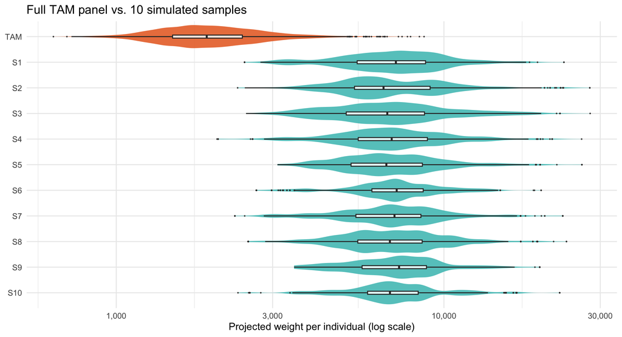

The full TAM panel (orange) sits far to the left at much smaller weights, while the 10 samples (teal) cluster tightly around ≈ 7,200 with similar, well-behaved spreads.

## Weight distributions, raincloud

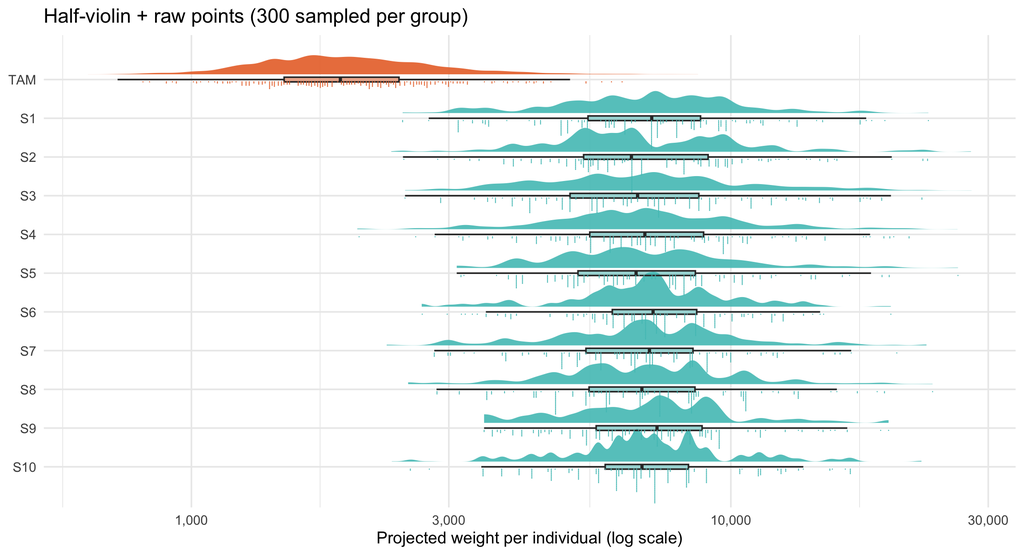

The raincloud adds the raw points (a 300-member sample per group) beneath each half-violin, making the actual data density visible alongside the smoothed shape and the box.

## Matching the spot list

The spot list contains GRPs already computed for the **Arab 15+ / million-plus cities** target group and covers the same week.

For every spot we compute:

> **GRPAbsolute** = sum of projected weights of all sample members watching the spot’s **channel** in the **minute the spot starts**, on the spot’s **date** — using that day’s weights.

The same calculation, applied to the filtered TAM panel with its official weights (`INDWgt`), reproduces the benchmark and validates the method.

Of the **1097 spots** in the list, **942** have a recalculated GRP matching the spots file and are kept for the comparison. The 10 samples found viewers for **546** of these — the remainder aired in minutes where no sampled panelist was watching that channel.

## GRP: full TAM vs. 10 samples

Table 3

GRP Absolute per spot

TAM benchmark vs. 10 simulated samples of 1,000 (S1–S10); only spots where the recalculation matches the spots file

| Product | Channel | Date | Start | Reference Spots file | Reference tx4 | Simulated samples S1 | Simulated samples S2 | Simulated samples S3 | Simulated samples S4 | Simulated samples S5 | Simulated samples S6 | Simulated samples S7 | Simulated samples S8 | Simulated samples S9 | Simulated samples S10 | Sample summary Mean | Sample summary CV |
| --- | --- | --- | --- | --- | --- | --- | --- | --- | --- | --- | --- | --- | --- | --- | --- | --- | --- |
| LOREAL PARIS ELVIVE GLYCOLIC GLOSS | ABU DHABI TV (M) | 2026-05-31 | 20:18:53 | 0 | 0 | 0 | 0 | 0 | 0 | 0 | 0 | 0 | 0 | 0 | 0 | 0 | — |
| LOREAL PARIS ELVIVE GLYCOLIC GLOSS | ABU DHABI TV (M) | 2026-05-28 | 20:59:07 | 0 | 0 | 0 | 0 | 0 | 0 | 0 | 0 | 0 | 0 | 0 | 0 | 0 | — |
| LOREAL PARIS ELVIVE GLYCOLIC GLOSS | ABU DHABI TV (M) | 2026-05-29 | 21:39:08 | 0 | 0 | 0 | 0 | 0 | 0 | 0 | 0 | 0 | 0 | 0 | 0 | 0 | — |
| LOREAL PARIS ELVIVE GLYCOLIC GLOSS | ABU DHABI TV (M) | 2026-05-28 | 21:39:33 | 0 | 0 | 0 | 0 | 0 | 0 | 0 | 0 | 0 | 0 | 0 | 0 | 0 | — |
| LOREAL PARIS ELVIVE GLYCOLIC GLOSS | ABU DHABI TV (M) | 2026-05-26 | 21:40:08 | 0 | 0 | 0 | 0 | 0 | 0 | 0 | 0 | 0 | 0 | 0 | 0 | 0 | — |
| LOREAL PARIS ELVIVE GLYCOLIC GLOSS | ABU DHABI TV (M) | 2026-05-25 | 21:40:53 | 0 | 0 | 0 | 0 | 0 | 0 | 0 | 0 | 0 | 0 | 0 | 0 | 0 | — |
| LOREAL PARIS ELVIVE GLYCOLIC GLOSS | ABU DHABI TV (M) | 2026-05-25 | 21:48:25 | 0 | 0 | 0 | 0 | 0 | 0 | 0 | 0 | 0 | 0 | 0 | 0 | 0 | — |
| LOREAL PARIS ELVIVE GLYCOLIC GLOSS | ABU DHABI TV (M) | 2026-05-26 | 21:48:44 | 0 | 0 | 0 | 0 | 0 | 0 | 0 | 0 | 0 | 0 | 0 | 0 | 0 | — |
| LOREAL PARIS ELVIVE GLYCOLIC GLOSS | ABU DHABI TV (M) | 2026-05-28 | 21:49:15 | 0 | 0 | 0 | 0 | 0 | 0 | 0 | 0 | 0 | 0 | 0 | 0 | 0 | — |
| LOREAL PARIS ELVIVE GLYCOLIC GLOSS | ABU DHABI TV (M) | 2026-05-31 | 21:57:08 | 0 | 0 | 0 | 0 | 0 | 0 | 0 | 0 | 0 | 0 | 0 | 0 | 0 | — |
| LOREAL PARIS ELVIVE GLYCOLIC GLOSS | ABU DHABI TV (M) | 2026-05-30 | 22:31:06 | 0 | 0 | 0 | 0 | 0 | 0 | 0 | 0 | 0 | 0 | 0 | 0 | 0 | — |
| LOREAL PARIS ELVIVE GLYCOLIC GLOSS | ABU DHABI TV (M) | 2026-05-31 | 22:35:21 | 0 | 0 | 0 | 0 | 0 | 0 | 0 | 0 | 0 | 0 | 0 | 0 | 0 | — |
| LOREAL PARIS ELVIVE GLYCOLIC GLOSS | ABU DHABI TV (M) | 2026-05-28 | 22:45:49 | 0 | 0 | 0 | 0 | 0 | 0 | 0 | 0 | 0 | 0 | 0 | 0 | 0 | — |
| LOREAL PARIS ELVIVE GLYCOLIC GLOSS | ABU DHABI TV (M) | 2026-05-27 | 22:52:01 | 0 | 0 | 0 | 0 | 0 | 0 | 0 | 0 | 0 | 0 | 0 | 0 | 0 | — |
| LOREAL PARIS ELVIVE GLYCOLIC GLOSS | ABU DHABI TV (M) | 2026-05-25 | 22:58:58 | 0 | 0 | 0 | 0 | 0 | 0 | 0 | 0 | 0 | 0 | 0 | 0 | 0 | — |
| LOREAL PARIS ELVIVE GLYCOLIC GLOSS | ABU DHABI TV (M) | 2026-05-26 | 22:59:28 | 0 | 0 | 0 | 0 | 0 | 0 | 0 | 0 | 0 | 0 | 0 | 0 | 0 | — |
| LOREAL PARIS ELVIVE GLYCOLIC GLOSS | ABU DHABI TV (M) | 2026-05-30 | 23:01:44 | 0 | 0 | 0 | 0 | 0 | 0 | 0 | 0 | 0 | 0 | 0 | 0 | 0 | — |
| LOREAL PARIS ELVIVE GLYCOLIC GLOSS | ABU DHABI TV (M) | 2026-05-26 | 23:09:02 | 0 | 0 | 0 | 0 | 0 | 0 | 0 | 0 | 0 | 0 | 0 | 0 | 0 | — |
| LOREAL PARIS ELVIVE GLYCOLIC GLOSS | ABU DHABI TV (M) | 2026-05-27 | 23:09:03 | 0 | 0 | 0 | 0 | 0 | 0 | 0 | 0 | 0 | 0 | 0 | 0 | 0 | — |
| LOREAL PARIS ELVIVE GLYCOLIC GLOSS | ABU DHABI TV (M) | 2026-05-25 | 23:11:27 | 0 | 0 | 0 | 0 | 0 | 0 | 0 | 0 | 0 | 0 | 0 | 0 | 0 | — |
| LOREAL PARIS ELVIVE GLYCOLIC GLOSS | ABU DHABI TV (M) | 2026-05-25 | 23:21:16 | 0 | 0 | 0 | 0 | 0 | 0 | 0 | 0 | 0 | 0 | 0 | 0 | 0 | — |
| LOREAL PARIS ELVIVE GLYCOLIC GLOSS | ABU DHABI TV (M) | 2026-05-28 | 23:21:33 | 0 | 0 | 0 | 0 | 0 | 0 | 0 | 0 | 0 | 0 | 0 | 0 | 0 | — |
| LOREAL PARIS ELVIVE GLYCOLIC GLOSS | ABU DHABI TV (M) | 2026-05-27 | 23:24:18 | 0 | 0 | 0 | 0 | 0 | 0 | 0 | 0 | 0 | 0 | 0 | 0 | 0 | — |
| LOREAL PARIS ELVIVE GLYCOLIC GLOSS | ABU DHABI TV (M) | 2026-05-28 | 23:24:23 | 0 | 0 | 0 | 0 | 0 | 0 | 0 | 0 | 0 | 0 | 0 | 0 | 0 | — |
| LOREAL PARIS ELVIVE GLYCOLIC GLOSS | ABU DHABI TV (M) | 2026-05-26 | 23:25:17 | 0 | 0 | 0 | 0 | 0 | 0 | 0 | 0 | 0 | 0 | 0 | 0 | 0 | — |
| LOREAL PARIS ELVIVE GLYCOLIC GLOSS | ABU DHABI TV (M) | 2026-05-25 | 23:37:14 | 0 | 0 | 0 | 0 | 0 | 0 | 0 | 0 | 0 | 0 | 0 | 0 | 0 | — |
| LOREAL PARIS ELVIVE GLYCOLIC GLOSS | ABU DHABI TV (M) | 2026-05-27 | 23:40:45 | 0 | 0 | 0 | 0 | 0 | 0 | 0 | 0 | 0 | 0 | 0 | 0 | 0 | — |
| LOREAL PARIS ELVIVE GLYCOLIC GLOSS | ABU DHABI TV (M) | 2026-05-29 | 23:49:52 | 0 | 0 | 0 | 0 | 0 | 0 | 0 | 0 | 0 | 0 | 0 | 0 | 0 | — |
| LOREAL PARIS ELVIVE GLYCOLIC GLOSS | ABU DHABI TV (M) | 2026-05-28 | 23:50:19 | 0 | 0 | 0 | 0 | 0 | 0 | 0 | 0 | 0 | 0 | 0 | 0 | 0 | — |
| LOREAL PARIS ELVIVE GLYCOLIC GLOSS | ABU DHABI TV (M) | 2026-05-26 | 23:53:34 | 0 | 0 | 0 | 0 | 0 | 0 | 0 | 0 | 0 | 0 | 0 | 0 | 0 | — |

[output cut: 912 more lines]

**CV — coefficient of variation:** how much the 10 samples disagree on a spot’s GRP — the standard deviation of the sample GRPs divided by their mean, as a percent. Low CV means the samples land on nearly the same GRP (a stable, reliable estimate); rows above 100% (highlighted in yellow) scatter more than their own average.

## Total campaign GRP

Table 4

| Source | GRP |
| --- | --- |
| TAM (spots file) | 10,294,001 |
| TAM (recalculated) | 10,293,974 |
| Sample 1 | 7,783,433 |
| Sample 2 | 9,127,964 |
| Sample 3 | 7,697,245 |
| Sample 4 | 8,709,946 |
| Sample 5 | 5,504,286 |
| Sample 6 | 9,226,647 |
| Sample 7 | 5,678,846 |
| Sample 8 | 8,846,760 |
| Sample 9 | 7,964,127 |
| Sample 10 | 11,159,598 |
| Sample mean | 8,169,885 |